# Tracking a Changing Climate

Point Blue staff collects weather data several times each day at the Palomarin Field Station to understand how short-term fluctuations in weather and long-term changes in climate affect bird populations. Understanding these changes requires long-term monitoring effort across decades!

### How has the climate changed?

To examine long-term weather patterns, we calculated annual average temperatures and total rainfall at Palomarin since 1975. Both measures have fluctuated over the last 40+ years, but temperatures have recently become much warmer. Through 2018, the most recent year of data included here, the hottest year we’ve recorded was in 2017. The wettest year we’ve recorded was in 1997-98 (during a strong El Nino). Recent years have been relatively dry, punctuated by a few wet winters.

[interactive chart not shown]

Average temperatures and rainfall recorded at the Palomarin Field Station each year, 1975–2018. Average temperatures are calculated from the average of the daily high and low temperatures. Rainfall totals are calculated from July through June of the following calendar year, to capture an entire winter rainy season.

### How are birds affected by weather and climate?

Weather plays a huge role in the daily lives of birds, and is a major driver of everything from successfully raising young, to surviving the winter, to migration timing, and even body size. Here are just a few examples of how our research has identified how birds are responding to global climate change.

#### Migration Timing

A changing climate may influence the seasonal timing (“phenology”) of blooming plants, hatching insects, and bird migration or nesting. In some cases, birds may not be able to easily change the timing of their migration to keep up with changes in the timing of their plant and insect food supplies, while others are shifting to try to stay in sync.

A 2018 study by Point Blue staff examined the dates migratory species arrive at Palomarin in the spring, and found that some species are arriving earlier (Orange-crowned Warbler), some are arriving later (Wilson’s Warbler), while others haven’t changed at all (Swainson’s Thrush).

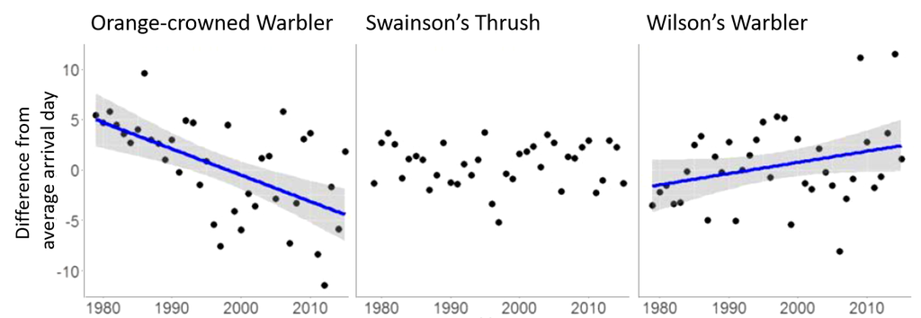

Arrival dates of migratory species to Palomarin each year, shown after subtracting its average arrival date over all years in the study, 1980-2016. When this difference is greater than zero, the species arrived later than average, and when this difference is less than zero, the species arrived earlier than average. The decreasing trend line for Orange-crowned Warbler indicates this species tends to arrive earlier each year.

For species that arrive at Palomarin in the fall, some species are arriving earlier (Golden-crowned Sparrow and Ruby-crowned Kinglet), while others haven’t changed at all (Fox Sparrow and Hermit Thrush). You can read more about this study by Point Blue staff Nadav Nur, Diana Humple, and Leo Salas in [Migratory Bird Arrivals](https://oehha.ca.gov/media/downloads/climate-change/report/2018caindicatorsreportmay2018.pdf), pages 232–242 in *Indicators of Climate Change in California*.

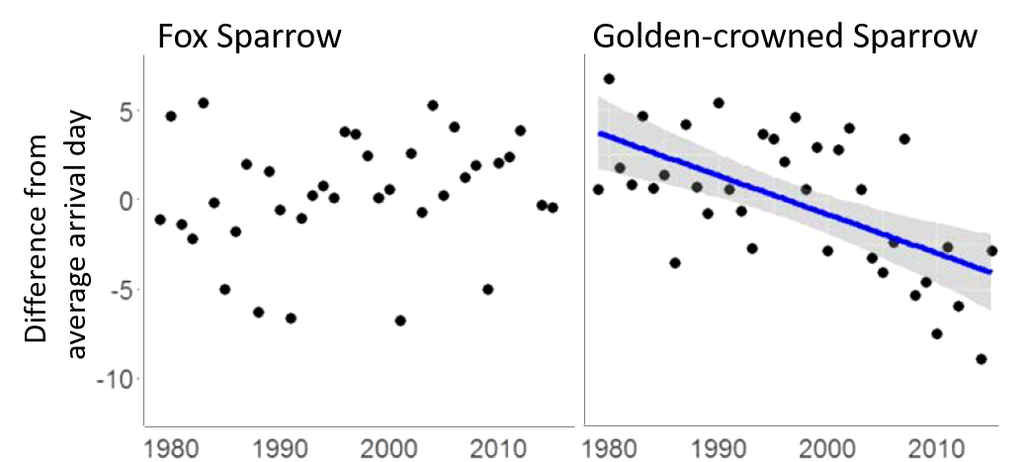

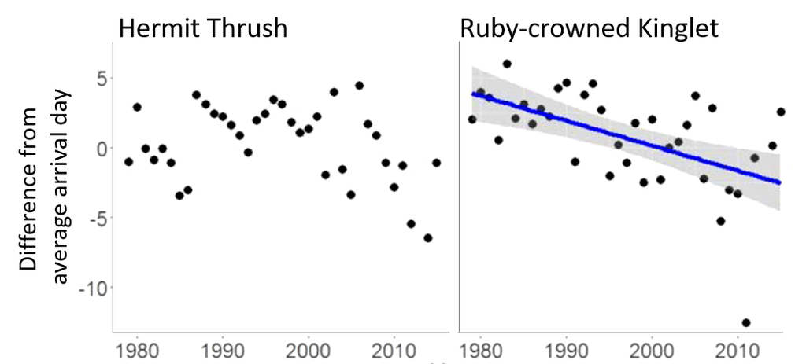

As in the previous figure, the arrival dates of migratory species to Palomarin each year are shown after subtracting its average arrival date over all years in the study, 1980-2016. When this difference is greater than zero, the species arrived later than average, and when this difference is less than zero, the species arrived earlier than average.

#### Body Size

Birds at Palomarin have been getting bigger! A [2012 study led by graduate student Rae Goodman](http://www.prbo.org/refs/files/12135_Goodman.pdf) uncovered this surprising finding using banding data from Palomarin and the San Francisco Bay Bird Observatory. Studies from other parts of the world have found that birds are getting smaller, thought to be related to increasing temperatures. In California, birds may be getting bigger in response to increasing variability in our climate.

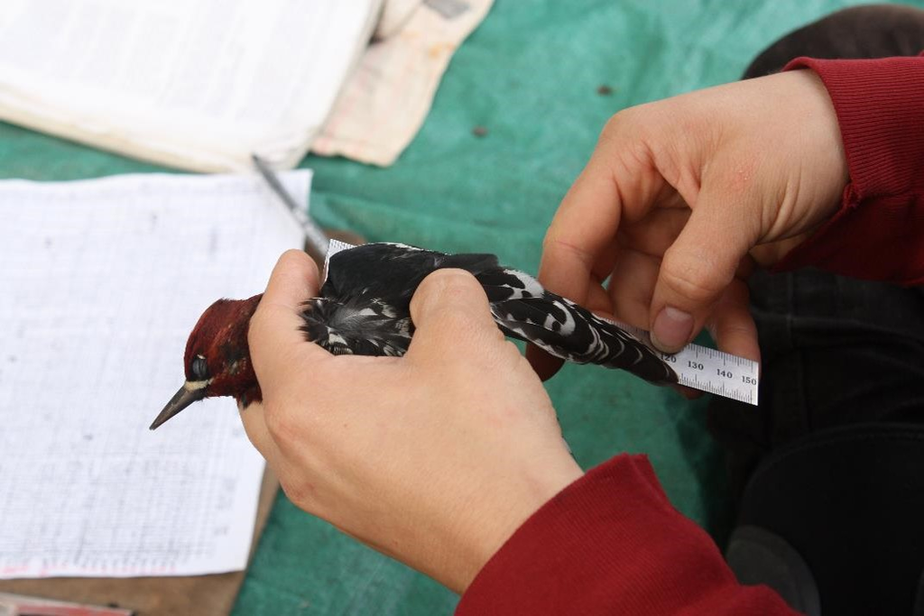

Measuring the wing chord (length) of a Red-breasted Sapsucker. Wing chord was one of the measurements found to be increasing over time. *Photo by Mark Dettling / Point Blue*

### Why is tracking weather and climate important for bird conservation?

These data demonstrate that many bird species are responding to climate change, and different species are responding in different ways. Our concern for bird conservation is that the rate at which our climate is changing may be outpacing the rate at which species can evolve and adapt to new conditions.

By collecting long-term data on species and how they are responding to changes in weather and climate, we are able to identify how birds are responding and which birds may be more vulnerable to climate change.

### How did we collect these data?

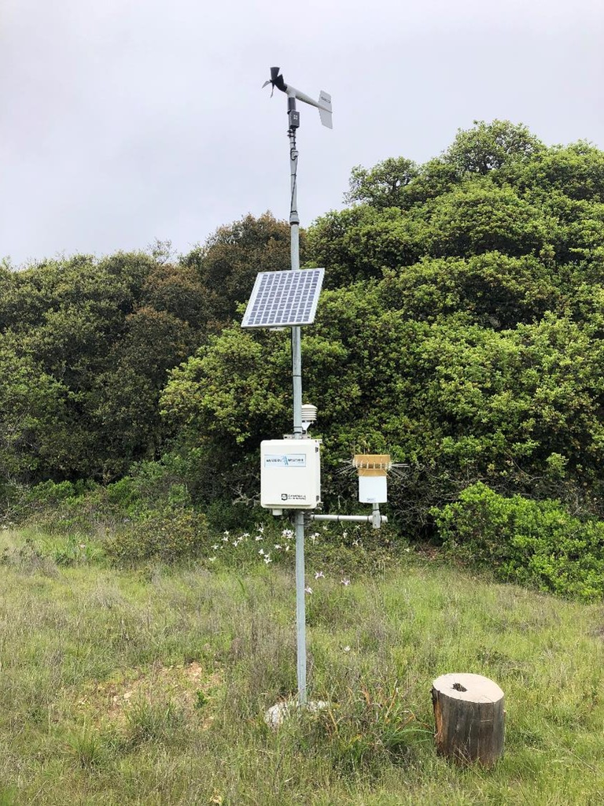

Solar-powered weather station at Palomarin that collects temperature, rain, and wind data. *Photo by Hilary Allen / Point Blue*

All of these data are collected by staff, volunteers, and especially the hundreds of interns who have trained at Palomarin over the years. The bird body size and arrival dates data come from our long-term mist netting and banding operation.

We have been collecting weather data since 1968, including daily records of precipitation, fog, temperature, cloud cover, wind, and barometric pressure data.

### Come visit!

Watch how we collect weather data during a bird banding demonstration! Visitors can drop in and join our intern and staff biologists to learn how we collect this data — and hopefully see a bird in the hand! [More information on visiting and scheduling groups.](https://www.pointblue.org/about-us/contact-visit-us/)

### More information

- Migratory bird arrivals. Pages 232–242 in *Indicators of Climate Change in California*. [[View PDF](https://oehha.ca.gov/media/downloads/climate-change/report/2018caindicatorsreportmay2018.pdf)]
- Avian body size changes and climate change: warming or increasing variability? Published in *Global Change Biology*. [[View PDF](http://www.prbo.org/refs/files/12135_Goodman.pdf)]
- Evidence of the effects of climate change on landbirds in western North America: A review and recommendations for future research. Published in *Western Field Ornithologists*. [[View PDF](http://www.prbo.org/refs/files/12453_Seavy_etal2018.pdf)]
- Projecting demographic responses to climate change: adult and juvenile survival respond differently to direct and indirect effects of weather in a passerine population. Published in *Global Change Biology*. [[View PDF](http://www.prbo.org/refs/files/12253_KristenE.Dybala2013.pdf)] [[Read summary](http://pointblue.org/wp-content/uploads/2018/06/2013_pubbrief_paentsvyoungsparrowsclimatechange_Dybala_GlobalChange.pdf)]